# Additional Plot Types and Plot Panels`

Author

Casey Schine

```r
library(tidyverse)
library(dslabs) # you might have to install this
library(ggridges)
library(patchwork) # you will probably need to install this
library(ggthemes)
```

## Notes on Progress

The standard will be going up. There are things that I have been explicitly asking for that will now be expected with every assignment.

### Assignment submission

1. The assignment format is .html. Any other formats turned in will lose you points. Formatting errors within your homework submission will also lose you points.
2. If you put an answer in a code chunk instead of in the body of the document, the answer will be treated as missing.

```r
# Answers to questions belong in the body of the document, not here in your code chunks. This is not an arbitrary thing. Your code chunks are collapsed and I have to go hunting for your answers if they are not in the body of the document. Additionally, you are learning how to properly format the combination of Markdown and R syntax so that they work together.
```

3. Formatting errors in your .html will result in points deductions.

Headers should show up as headers. Answers to questions should show up on a different line than the question, and not just read as a continuation of the question. **If you do not put a full line between the question and your answer, the answer will appear as a continuation of the paragraph containing the question.**

Please look over your rendered .html before submitting it. This should solve a lot of the formatting issues that I’ve been seeing.

### Plots

1. All plots will have appropriate axis labels, title, and scaling. I will not be asking for this explicitly moving forward, but it will be expected.
2. Plot types must be used appropriately (geom_col/geom_bar is rarely the right choice).

```r
library(forcats)
library(kableExtra)

data("gss_cat")
```

Here are some examples I compiled. These are my versions of some issues that I came across:

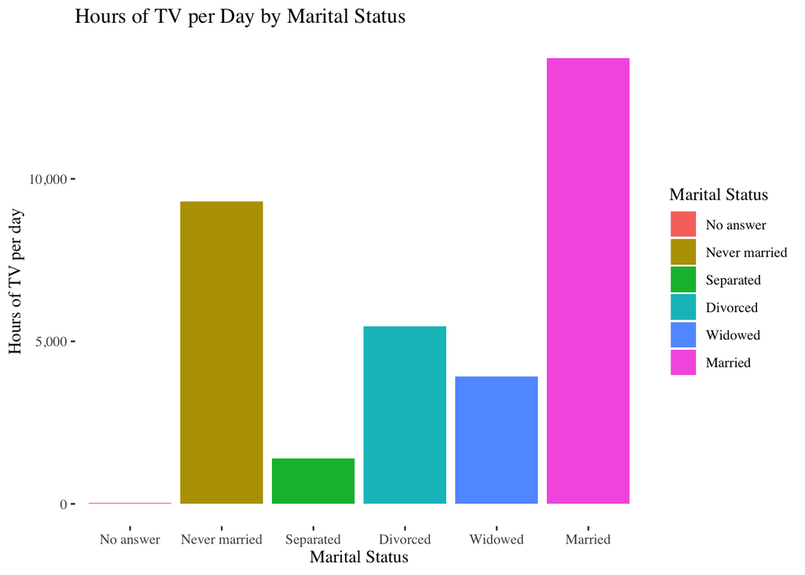

```r
gss_mod <- gss_cat |>
  group_by(marital) |>
  mutate(count_marital = n()) |> #count how many people in each category
  mutate(marital = fct_reorder(marital, count_marital, .fun=median, .na_rm = TRUE)) #reorder fct by count

gss_mod |>
  ggplot()+
  geom_col(aes(x=marital, y=tvhours, fill=marital)) +
  #scale_fill_brewer(palette="Accent") +
  scale_y_continuous(labels = scales::label_comma()) +
  theme_tufte() +
  labs(x="Marital Status", y="Hours of TV per day", fill="Marital Status")+
  ggtitle("Hours of TV per Day by Marital Status")
```

I believe that Married people might watch a lot of television, but more than 10,000 hours per day seems excessive.

Here are some examples of what you can do with `geom_bar()` and `geom_col()`

You can get counts of people in a category and sort within each category by different groups.

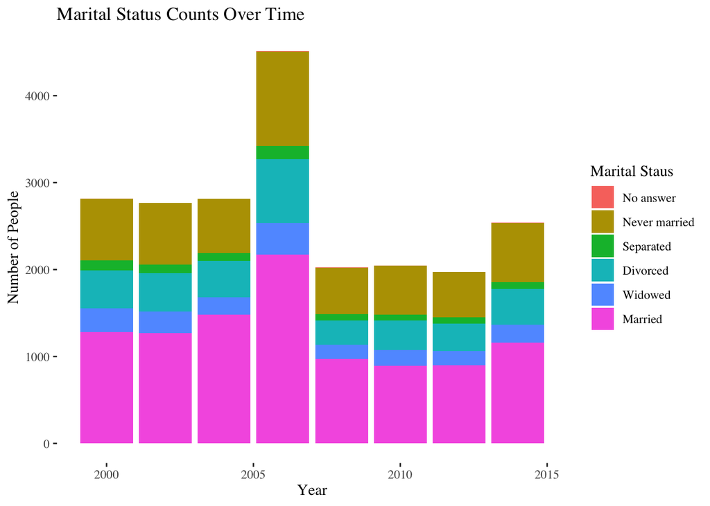

```r
gss_mod |>
  ggplot(aes(x = year, fill = marital)) +
  geom_bar() +
  labs(x = "Year", y = "Number of People", fill="Marital Staus") +
  ggtitle("Marital Status Counts Over Time") +
  theme_tufte()
```

Or, you can feed in summarized data.

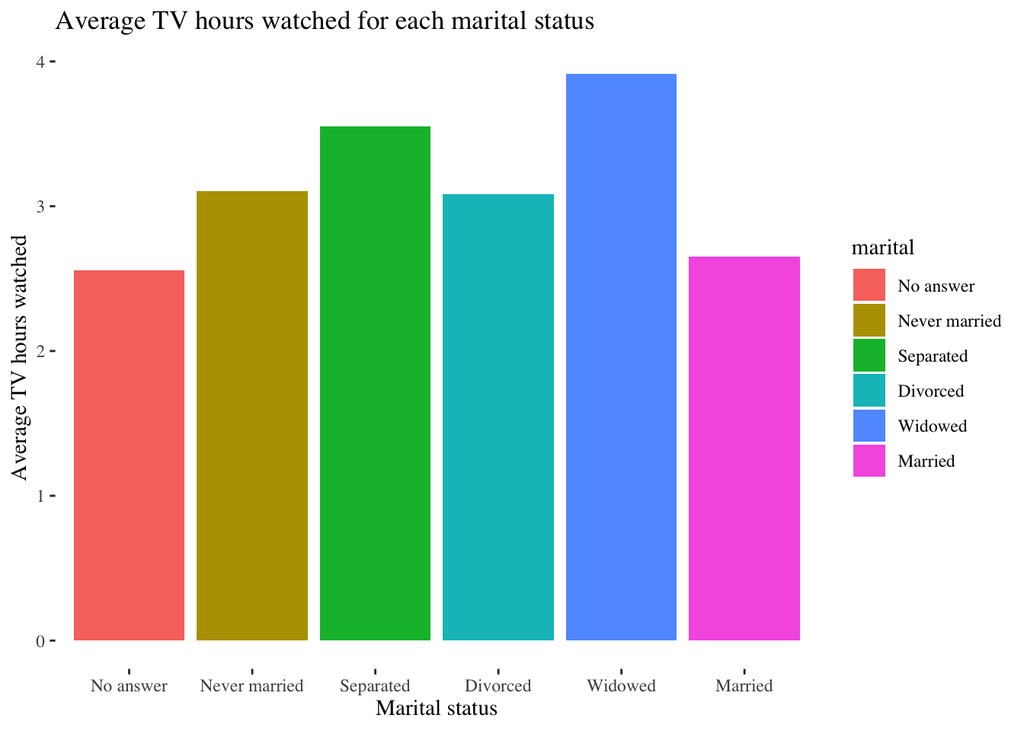

```r
gss_mod |>
  group_by(marital) |>
  summarize(mean_tv = mean(tvhours, na.rm = TRUE)) |>
  ggplot(aes(x = marital, y = mean_tv, fill = marital)) +
  geom_col() +
  labs(x = "Marital status",
    y = "Average TV hours watched",
    title = "Average TV hours watched for each marital status") +
  theme_tufte()
```

Here we are looking at the average hours of TV per day for each category.

3. Plots should pass a basic sanity check. If the output is clearly unrealistic, I expect you to recognize that and investigate rather than presenting it as-is.

An example is when we were making chloropleth maps. And we came across the impressively robust Antarctic economy.

```r
library(sf)
library(rnaturalearth)
library(rnaturalearthdata)

world <- ne_countries(scale = "medium", returnclass = "sf")

world <- world |>
  mutate(gdp_per_cap = gdp_md*1000000/pop_est)
```

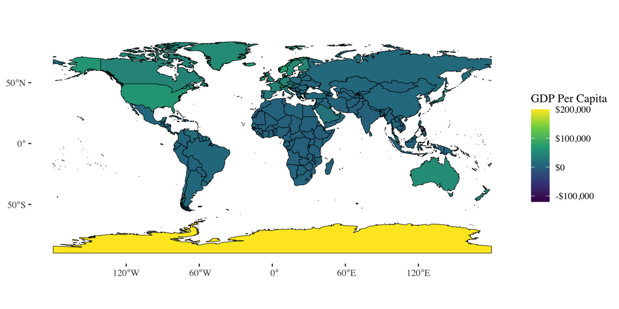

```r
world |>
ggplot() +
  geom_sf(aes(fill=gdp_per_cap), color="black") +
  scale_fill_viridis_c(labels = scales::label_dollar()) +
  labs(fill = "GDP Per Capita") +
  theme_tufte()
```

This figure shows that Antarctica (not even a country!) has the highest GDP per capita in the world, and also, somewhere on this map lurks a country with a negative GDP per capita???

What can we do about this?

```r
# first let's figure out what is causing the negative GDP
world |>
  filter(gdp_per_cap < 0) |>
  select(sovereignt, type, admin, pop_est, gdp_md, gdp_per_cap)
```

```
Simple feature collection with 1 feature and 6 fields
Geometry type: MULTIPOLYGON
Dimension:     XY
Bounding box:  xmin: 12.42754 ymin: 41.89756 xmax: 12.43916 ymax: 41.9062
Geodetic CRS:  WGS 84
  sovereignt              type   admin pop_est gdp_md gdp_per_cap
1    Vatican Sovereign country Vatican     825    -99     -120000
                        geometry
1 MULTIPOLYGON (((12.43916 41...
```

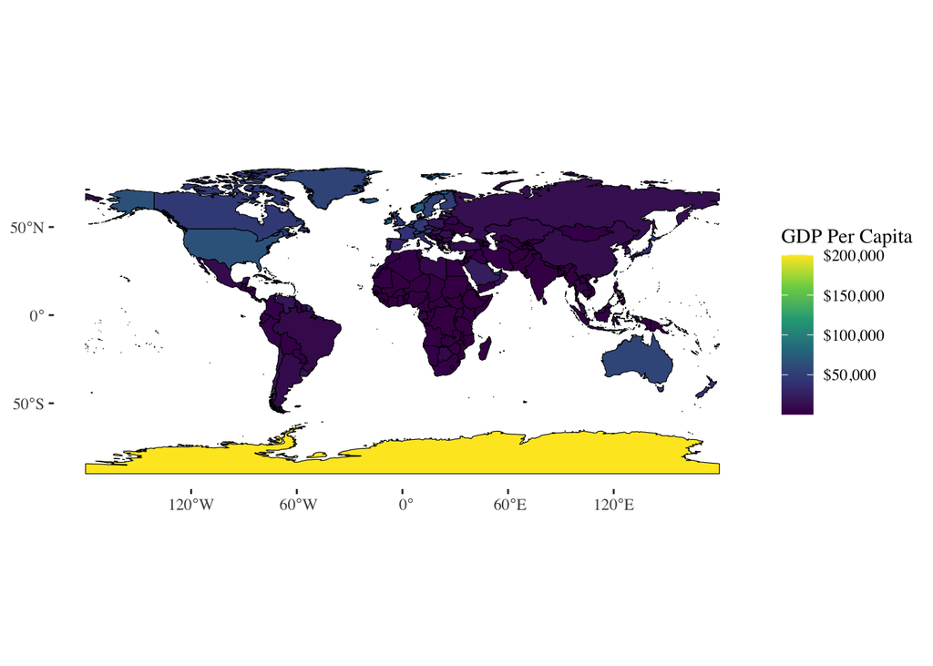

```r
# then let's do something about it and make a new map

world |>
    filter(gdp_per_cap > 0) |>
ggplot() +
  geom_sf(aes(fill=gdp_per_cap), color="black") +
  scale_fill_viridis_c(labels = scales::label_dollar()) +
  labs(fill = "GDP Per Capita") +
  theme_tufte()
```

```r
# now let's handle Antarctica

# first what is causing this???
# select(sovereignt, type, admin, pop_est, gdp_md, gdp_per_cap)
```

```r
# now let's do something about it
# what can we do??

# Get rid of it entirely?

# log scale??

# set to NA??
```

### New Challenges

Homework assignments will now include some things that I have not explicitly taught in class. This is intentional. A big part of data science is learning how to learn by reading documentation, searching for examples, and trying things that don’t work the first time. I’m not expecting perfection, but I am expecting you to engage with that process.

Getting stuck, showing what you tried, and explaining your thinking are an acceptable answer to these requests.

I would discourage relying on generative AI for this. Aside from access issues and incorrect answers, it often short-circuits the learning process. The answers you need are usually better found in package documentation, forums, and places like Stack Exchange.

If you have not attended drop-in tutoring or office hours, these are also great times to get help when you are stuck on this kind of thing.

## Additional Plot Types + Patchwork

Today is about expanding your plotting toolkit.

Each of these plots answers a different kind of question.

```r
library(tidyverse)
library(dslabs) # you might have to install this
library(ggridges)
library(patchwork)
library(ggthemes)

data(gapminder)
df <- gapminder
```

## Heatmap (Summary Across Two Variables)

**What this is:**  
A heatmap can show a summary statistic or counts across two variables.

**When to use it:**  
- When you want to compare how a value changes across two dimensions  
- When you care about patterns across a grid (time × group, location × category, etc.)

**Why it’s useful:**  
- It reveals trends and contrasts quickly  
- It avoids clutter compared to many separate plots

Summarize life expectancy by continent and year.

```r
df_summary <- df |>
  group_by(continent, year) |>
  summarize(mean_lifeExp = mean(life_expectancy),
            mean_fert=mean(fertility),
            .groups = "drop")
```

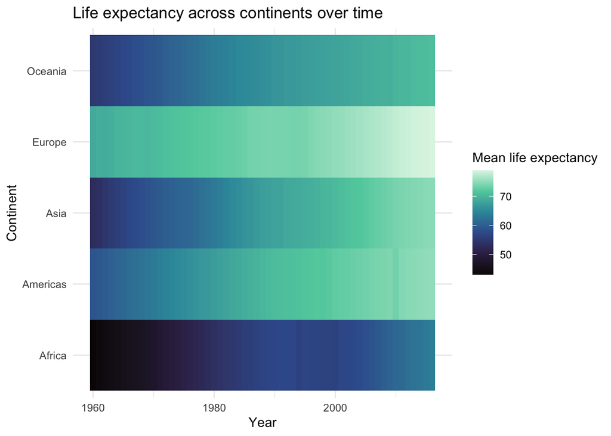

```r
p1 <- ggplot(df_summary, aes(x = year, y = continent, fill = mean_lifeExp)) +
  geom_tile() +
  scale_fill_viridis_c(option="mako") +
  labs(fill = "Mean life expectancy",
    title = "Life expectancy across continents over time",
    x = "Year", y = "Continent") +
  theme_minimal()

p1
```

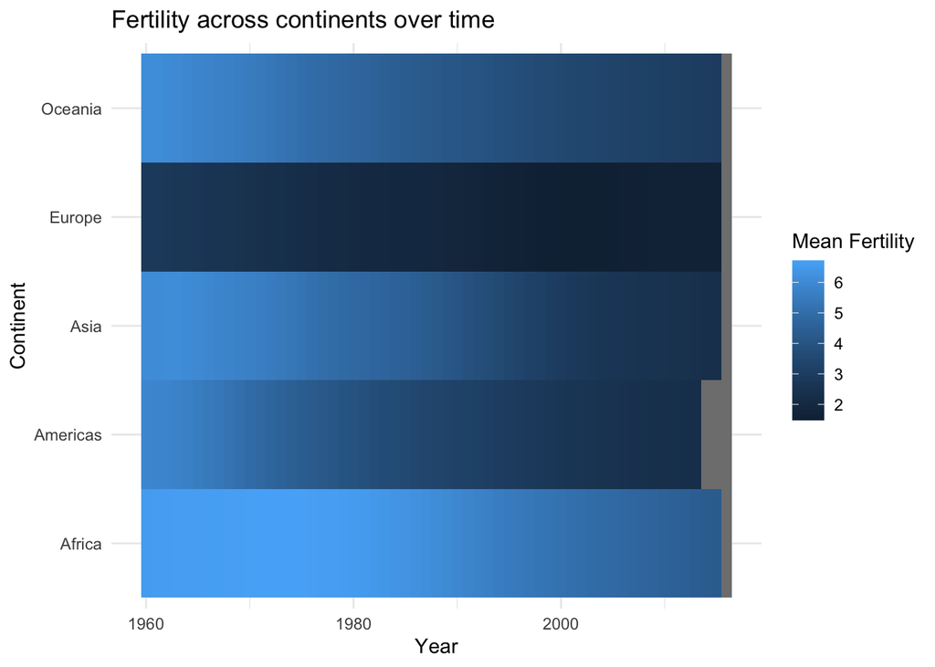

```r
ggplot(df_summary, aes(x = year, y = continent, fill = mean_fert)) +
  geom_tile() +
  labs(
    fill = "Mean Fertility",
    title = "Fertility across continents over time",
    x = "Year", y = "Continent") +
  theme_minimal()
```

## Ridgeline Plot (Distribution Across Groups)

**What this is:**  
A ridgeline plot shows multiple distributions stacked on top of each other.

**When to use it:**  
- When comparing a continuous variable across groups  
- When you care about the *shape* of the distribution, not just the mean

**Why it’s useful:**  
- It shows skew, spread, and multiple peaks  
- It’s more informative than boxplots for distribution shape

Compare life expectancy across continents.

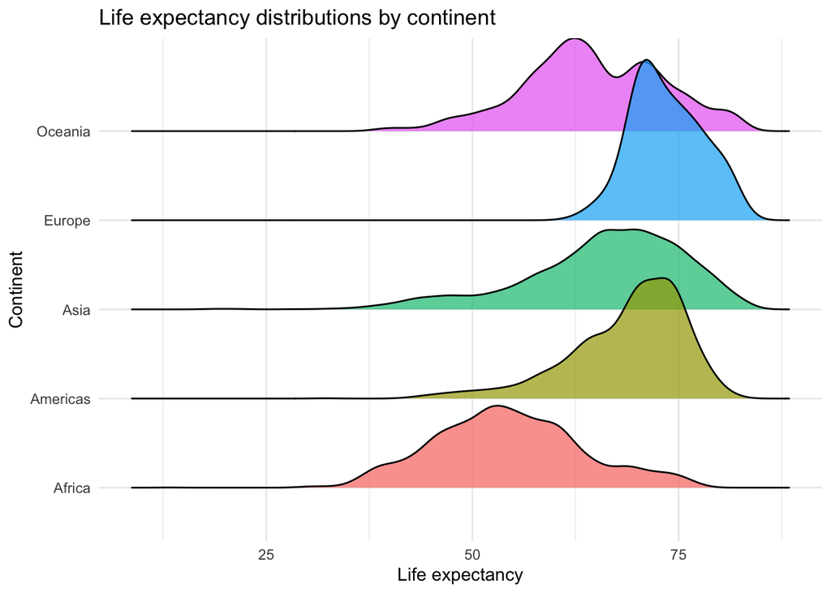

```r
ggplot(df, aes(x = life_expectancy, y = continent, fill = continent)) +
  geom_density_ridges(alpha = 0.7) +
  labs(title = "Life expectancy distributions by continent",
    x = "Life expectancy", y = "Continent") +
  theme_minimal() +
  theme(legend.position = "none")
```

You can mess around with some options to alter aspects of the plot.

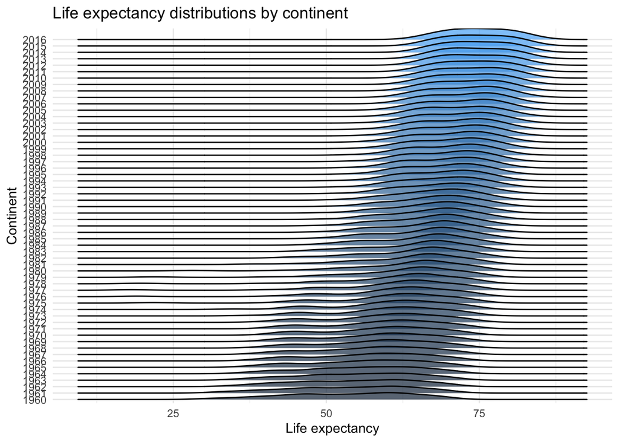

```r
df |>
  filter(continent=="Asia") |>
ggplot(aes(x = life_expectancy, y = factor(year), fill = year)) +
  geom_density_ridges(alpha = 0.7) +
  labs(title = "Life expectancy distributions by continent",
    x = "Life expectancy", y = "Continent") +
  theme_minimal() +
  theme(legend.position = "none")
```

## 2D Density Plot

**What this is:**  
A 2D density plot shows where observations are concentrated in two continuous variables.

**When to use it:**  
- When a scatterplot has too many points  
- When you want to emphasize structure rather than individual observations

**Why it’s useful:**  
- It reveals clusters and patterns that are hard to see in scatterplots  
- It reduces overplotting

Look at the relationship between GDP and life expectancy.

### `geom_density_2d_filled`

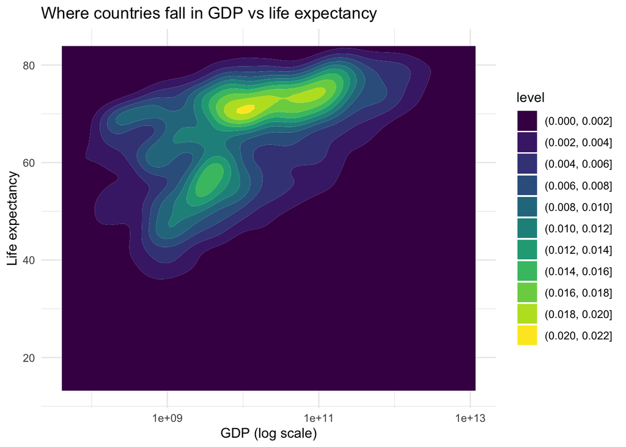

```r
p3 <- ggplot(df, aes(x = gdp, y = life_expectancy)) +
  geom_density_2d_filled() +
  scale_x_log10() +
  labs(title = "Where countries fall in GDP vs life expectancy",
    x = "GDP (log scale)",y = "Life expectancy") +
  theme_minimal()

p3
```

### `geom_density_2d` with`geom_point()`

Frequently I like to see the actual data in addition to information on where the data are most dense. To do this I would combine a point plot with a gensity contour plot.

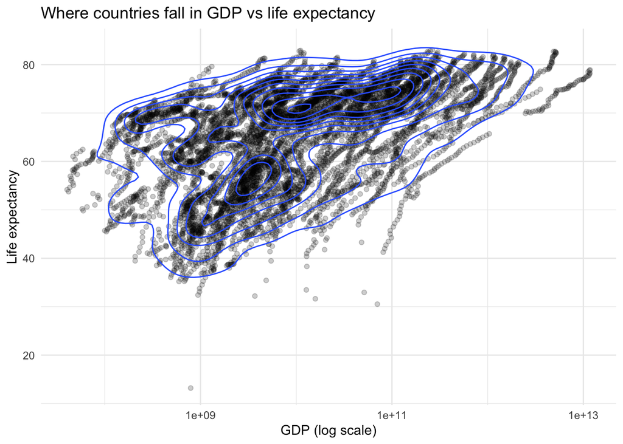

```r
# same plot with geom_point() overlaid with geom_density_2d()

ggplot(df, aes(x = gdp, y = life_expectancy)) +
  geom_point( alpha=0.2) +
  geom_density_2d() +
  scale_x_log10() +
  labs(title = "Where countries fall in GDP vs life expectancy",
    x = "GDP (log scale)",y = "Life expectancy") +
  theme_minimal()
```

### `geom_hex()`

There are other ways to visualize data density, such as a hex density plot. This creates a layer of hexagisn and tells you how many points fall within the boundaries of each hexagon.

```r
#same plot with geom_hex()
```

## Small Multiples (Faceting)

**What this is:**  
Small multiples show the same plot repeated across subsets of the data.

**When to use it:**  
- When comparing patterns across groups  
- When overlaying everything in one plot becomes too crowded

**Why it’s useful:**  
- It makes comparisons clearer by separating groups  
- It keeps the same axes, so differences are easier to see

To demonstrate this type of plot, let’s look at the relationship between fertility and life expectancy across continents and years.

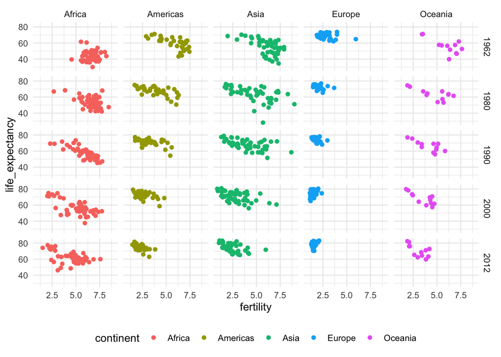

```r
# aes(fertility, life_expectancy, col = continent)
# Use a subset of years by using filter(year %in% years)
years <- c(1962, 1980, 1990, 2000, 2012)

# use facet_grid(year ~ continent) rather than facet_wrap() to create a grid of both year and continent

df |> filter(year %in% years) |>
ggplot(aes(fertility, life_expectancy, col = continent)) +
  geom_point() +
  facet_grid(year ~ continent) +
  theme_minimal() +
  theme(legend.position = "bottom")
```

```r
# what happens if we use facet_wrap(year ~ continent) instead???
```

Here is another example, looking at the relationship between life expectancy and GDP per capita across years.

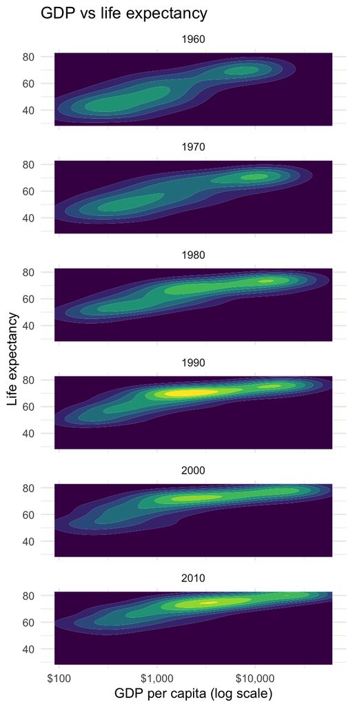

```r
# use filter(year %in% c(1960, 1970, 1980, 1990, 2000, 2010)) to select 6 different years at a 10-year interval

# aes(x = gdp/population, y = life_expectancy)

# use geom_density_2d_filled()
# use scale_x_log10(labels=scales::label_dollar()) to get good axis scaling

df |>
  filter(year %in% c(1960, 1970, 1980, 1990, 2000, 2010)) |>
ggplot(aes(x = gdp/population, y = life_expectancy)) +
  geom_density_2d_filled() +
  scale_x_log10(labels=scales::label_dollar()) +
  labs(title = "GDP vs life expectancy",
    x = "GDP per capita (log scale)",y = "Life expectancy") +
  theme_minimal() +
  theme(legend.position="none") +
  facet_wrap(~year, ncol=1)
```

```r
# make the same plot with geom_point() and geom_density_2d()
```

And here is another example using `geom_density_ridges()` to accomplish a similar effect to faceting. This particular geom can be really effective in showing a changing distribution over time.

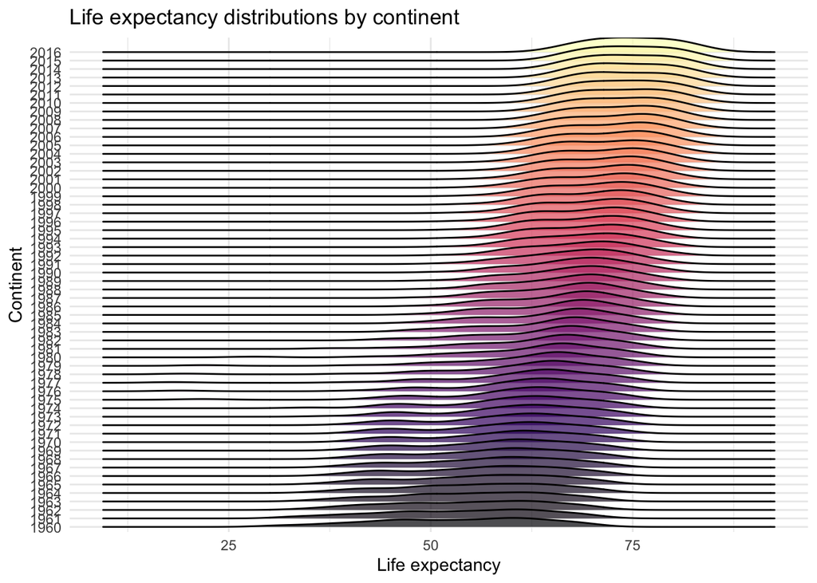

```r
# filter for just Asia
# aes(x = life_expectancy, y = factor(year), fill = year)

df |>
  filter(continent=="Asia") |>
ggplot(aes(x = life_expectancy, y = factor(year), fill = year)) +
  geom_density_ridges(alpha = 0.7) +
  scale_fill_viridis_c(option="magma") +
  labs(title = "Life expectancy distributions by continent",
    x = "Life expectancy", y = "Continent") +
  theme_minimal() +
  theme(legend.position = "none")
```

## Patchwork

**What this is:**  
Patchwork allows you to combine multiple plots into a single figure.

**When to use it:**  
- When one plot is not enough to answer your question  
- When building an argument using multiple pieces of evidence

**Why it’s useful:**  
- It lets you organize plots into a clear structure  
- It turns individual plots into a coherent figure

First let’s remake some of the plots from above to use with patchwork.

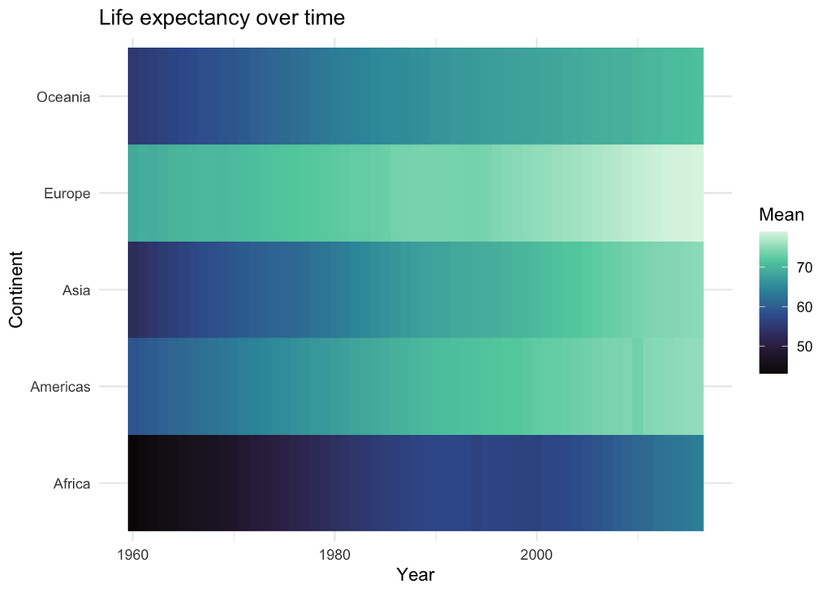

```r
p1 <- ggplot(df_summary, aes(x = year, y = continent, fill = mean_lifeExp)) +
  geom_tile() +
  scale_fill_viridis_c(option="mako") +
  labs(fill = "Mean",
    title = "Life expectancy over time",
    x = "Year", y = "Continent") +
  theme_minimal()

p1
```

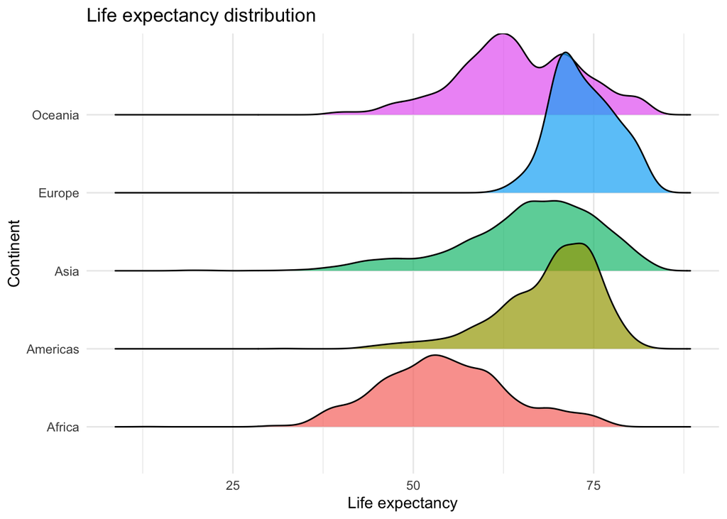

```r
p2 <- ggplot(df, aes(x = life_expectancy, y = continent, fill = continent)) +
  geom_density_ridges(alpha = 0.7) +
  labs(title = "Life expectancy distribution",
    x = "Life expectancy", y = "Continent") +
  theme_minimal() +
  theme(legend.position = "none")

p2
```

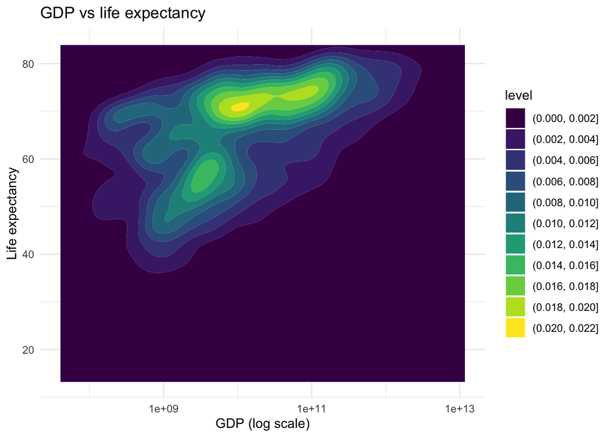

```r
p3 <- ggplot(df, aes(x = gdp, y = life_expectancy)) +
  geom_density_2d_filled() +
  scale_x_log10() +
  labs(title = "GDP vs life expectancy",
    x = "GDP (log scale)",y = "Life expectancy") +
  theme_minimal()

p3
```

The syntax for patchwork at it’s most basic is very simple. You can use `|` or `+` to place plots side-by-side:

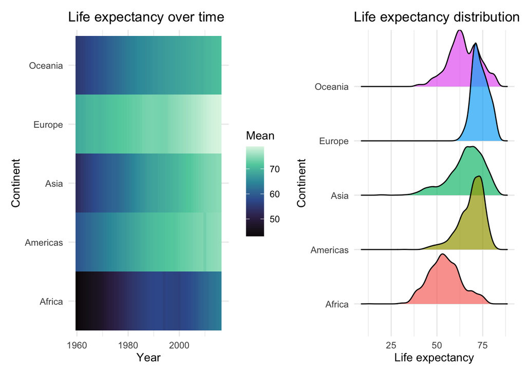

```r
# side-by-side using | between plot objects
p1 | p2
```

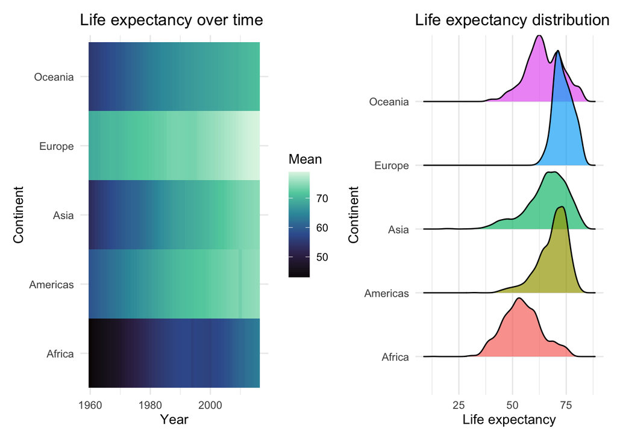

```r
# or side-by-side using + between plot objects
p1 + p2
```

You can use `/` to stack plots:

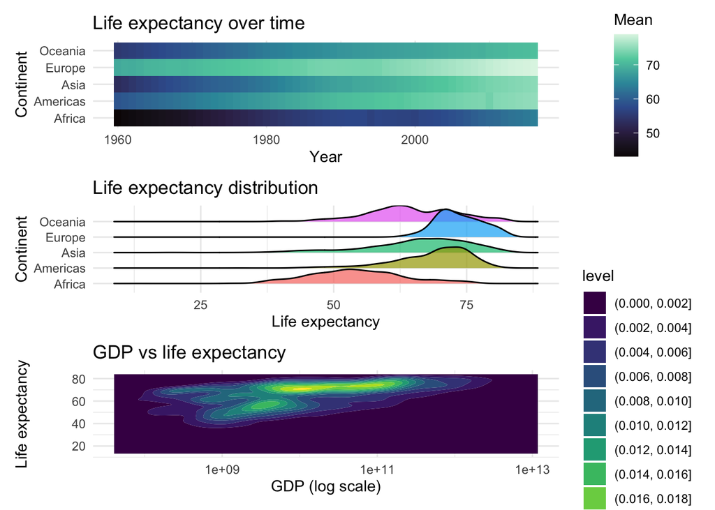

```r
# stacked using / between plot objects
p1 / p2 / p3
```

You can also combine notation to put 2 plots on one row and one on another.

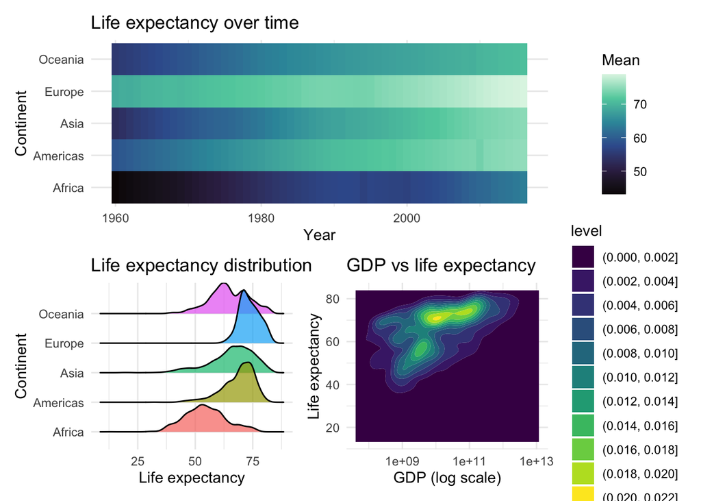

```r
# combine for more options putting 2 plots on one row and one on another for example
# e.g. p1 / (p2 | p3)

p1 / (p2 | p3)
```

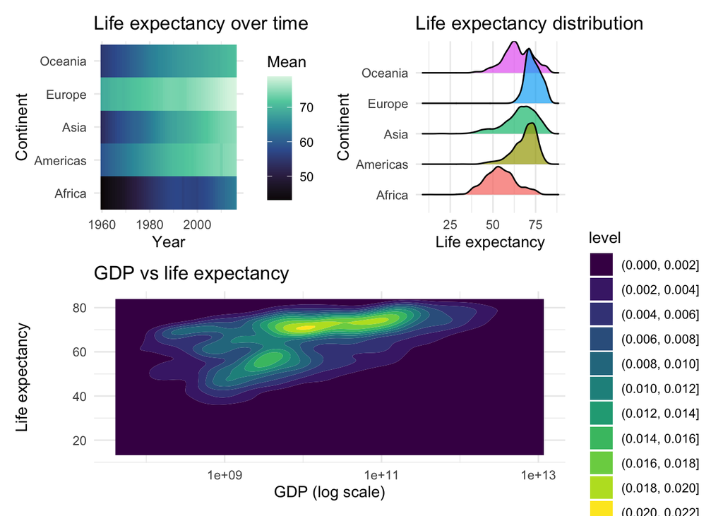

```r
(p1 | p2) / p3
```

Use `plot_layout(guides="collect")` to have all of the legends grouped together on the side of the panel. Or if plots use the same legend, they will be combined into a single legend for the entire panel.

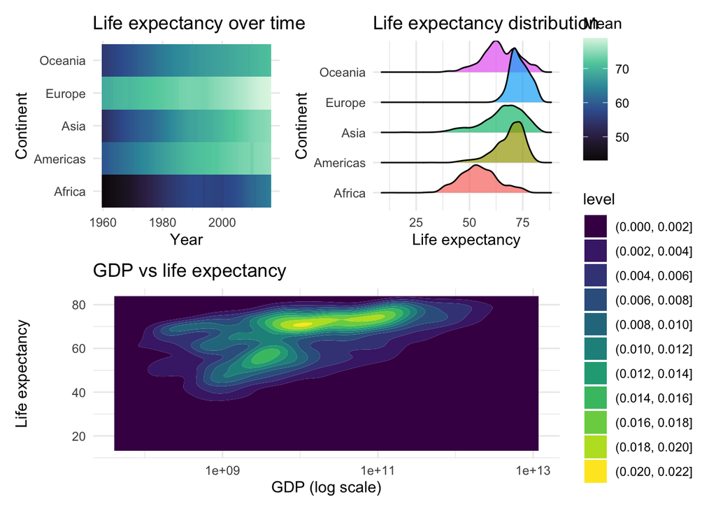

```r
# Use plot_layout(guides="collect")

(p1 | p2) / p3 +
  plot_layout(guides = "collect")
```

If we were to render this document, this first plot, comes out a bit of a mess, with lots of overlapping elements. So, let’s control the size of the output and give it a little more room by setting the figure height to 6 and the width to 7 in the code chunk header.

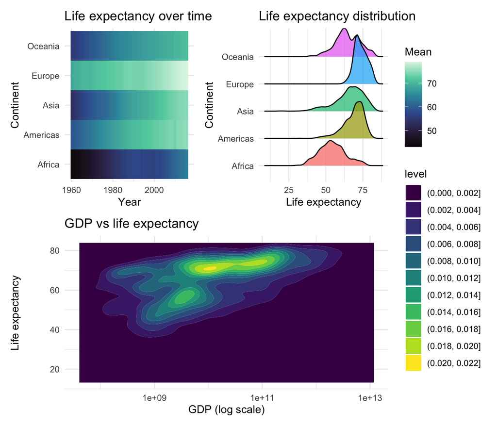

```r
# same plot with fig.height=6, and fig. width=7 in code chunk header
(p1 | p2) / p3 +
  plot_layout(guides = "collect")
```

Use `heights` within the `plot_layout` function to control the relative heights of the plot rows.

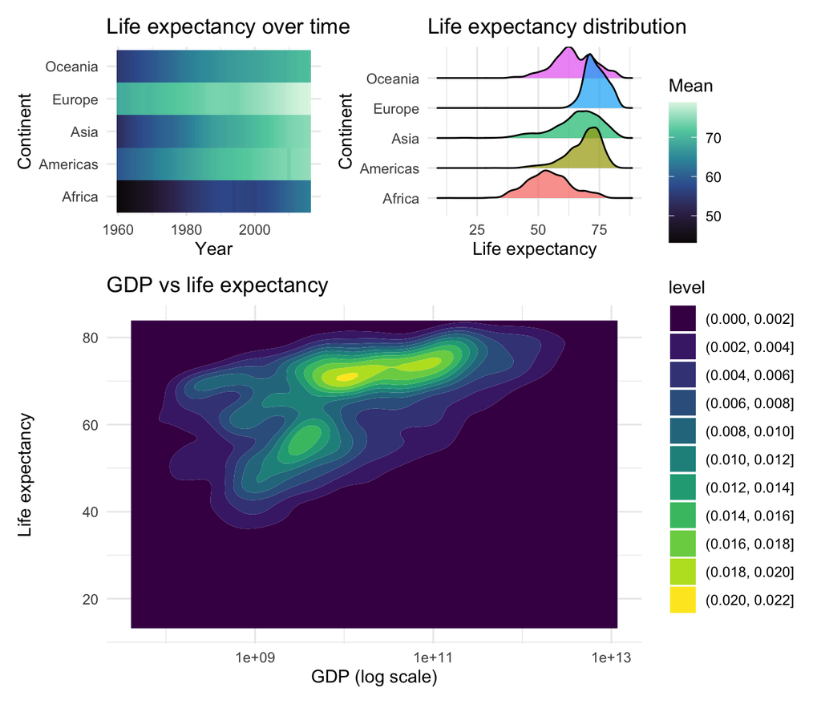

```r
# set  heights = c(1, 2) within plot_layout()

(p1 | p2) / p3 +
  plot_layout(guides = "collect", heights = c(1, 2))
```

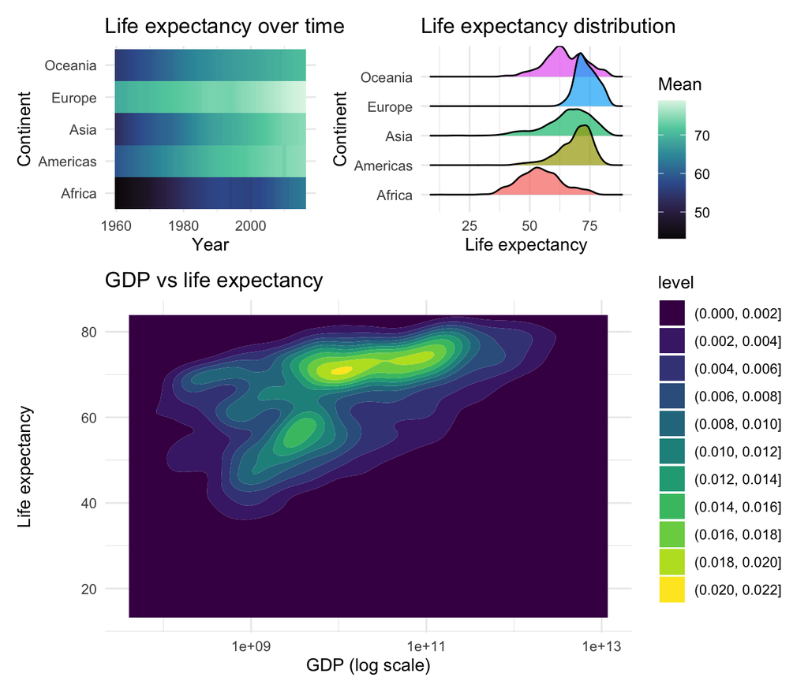

```r
# change height ratios for two plot rows.

((p1 | p2) / p3) +
  plot_layout(guides = "collect", heights = c(1, 2))
```

And finally, you can add a title to the entire panel using the `plot_annotation()` function and setting `title=` to your title of choice.

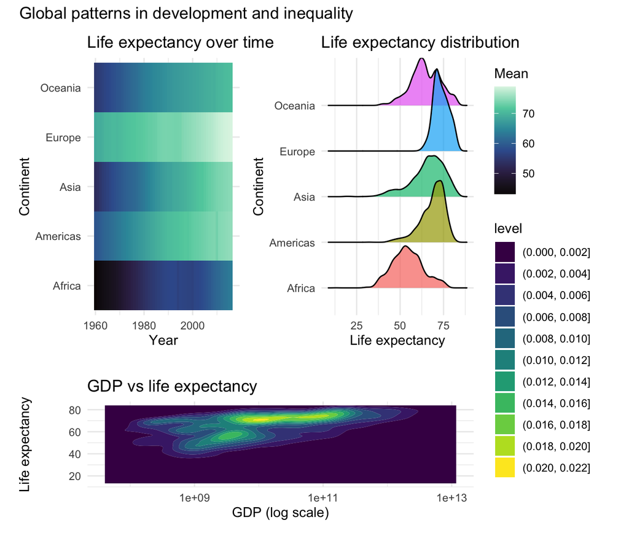

```r
((p1 | p2) / p3) +
  plot_layout(guides = "collect", heights = c(3, 1)) +
  theme(plot.margin = margin(20, 20, 10, 10)) +
  plot_annotation(title = "Global patterns in development and inequality")
```

There are even more ways that you can manipulate options in patchwork. This is just a sampling of the most fundamental options. You can also play around with margins and many other things.